# SDSS Classification

This data set is imbalanced, so we should *eventually* be using some kind of data balancing algorithm (e.g. *SMOTE*)

```python
# imports
from pathlib import Path

import pandas as pd
import numpy as np
import plotly
import plotly.express as px
import plotly.graph_objects as go
import plotly.offline as pyo
from plotly.subplots import make_subplots



from sklearn.model_selection import train_test_split
```

```python
# Read in the dataset
# there are two, we'll be using stellar_classification.csv
data_dir = Path("./data")
print(f"{data_dir.exists() = }")

data_file = data_dir / "star_classification.csv"
print(f"{data_file.exists() = }")

df = pd.read_csv(data_file)
```

```
data_dir.exists() = True
data_file.exists() = True
```

## EDA + Feature Engineering

Data description taken from the Kaggle page (https://www.kaggle.com/datasets/fedesoriano/stellar-classification-dataset-sdss17):

The data consists of 100,000 observations of space taken by the SDSS (Sloan Digital Sky Survey). Every observation is described by 17 feature columns and 1 class column which identifies it to be either a star, galaxy or quasar.

1. `obj_ID` = Object Identifier, the unique value that identifies the object in the image catalog used by the CAS
2. `alpha` = Right Ascension angle (at J2000 epoch)
3. `delta` = Declination angle (at J2000 epoch)
4. `u` = Ultraviolet filter in the photometric system
5. `g` = Green filter in the photometric system
6. `r` = Red filter in the photometric system
7. `i` = Near Infrared filter in the photometric system
8. `z` = Infrared filter in the photometric system
9. `run_ID` = Run Number used to identify the specific scan
10. `rereun_ID` = Rerun Number to specify how the image was processed
11. `cam_col` = Camera column to identify the scanline within the run
12. `field_ID` = Field number to identify each field
13. `spec_obj_ID` = Unique ID used for optical spectroscopic objects (this means that 2 different observations with the same spec_obj_ID must share the output class)
14. `class` = object class (galaxy, star or quasar object)
15. `redshift` = redshift value based on the increase in wavelength
16. `plate` = plate ID, identifies each plate in SDSS
17. `MJD` = Modified Julian Date, used to indicate when a given piece of SDSS data was taken
18. `fiber_ID` = fiber ID that identifies the fiber that pointed the light at the focal plane in each observation

I can easily throw away `obj_ID`, `alpha`, `delta`, `run_ID`, `rerun_ID`, `cam_col`, `field_ID`, `spec_obj_id`, `plate`, `MJD`, `fiber_ID`

A lot of these columns are identifies for the SDSS system. `alpha` and `delta` describe positional information in relation to the night sky. I don't anticipate position being indicative of object class.

However, `redshift` is also an measure of position. "Redshift" is a measure of how far away an object is from us, the observer. There might be some correlation between far away objects being a `GALAXY`, `STAR`, or `QSO`, so I'll leave it in for now.

So the features used:

`u` `g` `r` `i` `z` and `redshift`

labels:

`class`

```python
# check for nulls
print(f"DF contains nulls = {df.isnull().values.any()}\n")

# check another way to confirm
df.isnull().sum()

# there are no nulls, but there are some -9999s, find those rows
print("Row with -9999.0")
display(df[df.isin([-9999.0]).any(axis=1)])


# just one row, so lets drop it and move on.
df = df[~df.isin([-9999.0]).any(axis=1)]
print("DF w/o -9999.0")
df
```

```
DF contains nulls = False

Row with -9999.0
```

|  | obj_ID | alpha | delta | u | g | r | i | z | run_ID | rerun_ID | cam_col | field_ID | spec_obj_ID | class | redshift | plate | MJD | fiber_ID |
| --- | --- | --- | --- | --- | --- | --- | --- | --- | --- | --- | --- | --- | --- | --- | --- | --- | --- | --- |
| 79543 | 1.237649e+18 | 224.006526 | -0.624304 | -9999.0 | -9999.0 | 18.1656 | 18.01675 | -9999.0 | 752 | 301 | 2 | 537 | 3.731277e+18 | STAR | 0.000089 | 3314 | 54970 | 162 |

```
DF w/o -9999.0
```

|  | obj_ID | alpha | delta | u | g | r | i | z | run_ID | rerun_ID | cam_col | field_ID | spec_obj_ID | class | redshift | plate | MJD | fiber_ID |
| --- | --- | --- | --- | --- | --- | --- | --- | --- | --- | --- | --- | --- | --- | --- | --- | --- | --- | --- |
| 0 | 1.237661e+18 | 135.689107 | 32.494632 | 23.87882 | 22.27530 | 20.39501 | 19.16573 | 18.79371 | 3606 | 301 | 2 | 79 | 6.543777e+18 | GALAXY | 0.634794 | 5812 | 56354 | 171 |
| 1 | 1.237665e+18 | 144.826101 | 31.274185 | 24.77759 | 22.83188 | 22.58444 | 21.16812 | 21.61427 | 4518 | 301 | 5 | 119 | 1.176014e+19 | GALAXY | 0.779136 | 10445 | 58158 | 427 |
| 2 | 1.237661e+18 | 142.188790 | 35.582444 | 25.26307 | 22.66389 | 20.60976 | 19.34857 | 18.94827 | 3606 | 301 | 2 | 120 | 5.152200e+18 | GALAXY | 0.644195 | 4576 | 55592 | 299 |
| 3 | 1.237663e+18 | 338.741038 | -0.402828 | 22.13682 | 23.77656 | 21.61162 | 20.50454 | 19.25010 | 4192 | 301 | 3 | 214 | 1.030107e+19 | GALAXY | 0.932346 | 9149 | 58039 | 775 |
| 4 | 1.237680e+18 | 345.282593 | 21.183866 | 19.43718 | 17.58028 | 16.49747 | 15.97711 | 15.54461 | 8102 | 301 | 3 | 137 | 6.891865e+18 | GALAXY | 0.116123 | 6121 | 56187 | 842 |
| ... | ... | ... | ... | ... | ... | ... | ... | ... | ... | ... | ... | ... | ... | ... | ... | ... | ... | ... |
| 99995 | 1.237679e+18 | 39.620709 | -2.594074 | 22.16759 | 22.97586 | 21.90404 | 21.30548 | 20.73569 | 7778 | 301 | 2 | 581 | 1.055431e+19 | GALAXY | 0.000000 | 9374 | 57749 | 438 |
| 99996 | 1.237679e+18 | 29.493819 | 19.798874 | 22.69118 | 22.38628 | 20.45003 | 19.75759 | 19.41526 | 7917 | 301 | 1 | 289 | 8.586351e+18 | GALAXY | 0.404895 | 7626 | 56934 | 866 |
| 99997 | 1.237668e+18 | 224.587407 | 15.700707 | 21.16916 | 19.26997 | 18.20428 | 17.69034 | 17.35221 | 5314 | 301 | 4 | 308 | 3.112008e+18 | GALAXY | 0.143366 | 2764 | 54535 | 74 |
| 99998 | 1.237661e+18 | 212.268621 | 46.660365 | 25.35039 | 21.63757 | 19.91386 | 19.07254 | 18.62482 | 3650 | 301 | 4 | 131 | 7.601080e+18 | GALAXY | 0.455040 | 6751 | 56368 | 470 |
| 99999 | 1.237661e+18 | 196.896053 | 49.464643 | 22.62171 | 21.79745 | 20.60115 | 20.00959 | 19.28075 | 3650 | 301 | 4 | 60 | 8.343152e+18 | GALAXY | 0.542944 | 7410 | 57104 | 851 |

99999 rows × 18 columns

```python
features = ["u", "g", "r", "i", "z", "redshift"]
labels = ["class"]
X = df[features]
Y = df[labels]

(X_train, X_test, Y_train, Y_test) = train_test_split(X, Y, test_size=0.2, random_state=42)
```

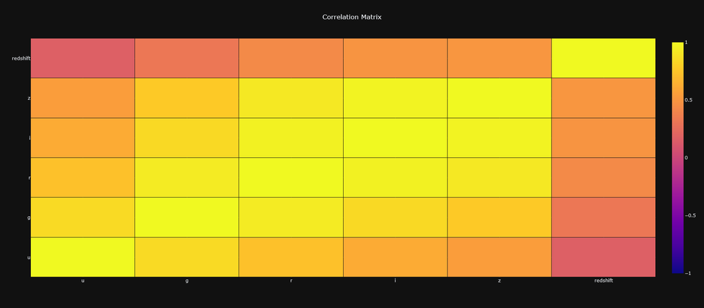

```python
# lets look at some correlations
corr_df = X_train.corr(numeric_only=True)

def plot_corr(df):
    fig = go.Figure()

    fig.add_trace(
        go.Heatmap(
            x=df.columns,
            y=df.index,
            z=df.values,
            xgap=1,
            ygap=1,
            zmin=-1,
            zmax=1


        )
    )

    fig.update_layout(
        template="plotly_dark",
        height=800,
        title={
            'text':'Correlation Matrix',
            'x' : 0.5
        }
    )
    return fig

fig = plot_corr(corr_df)
plotly.offline.iplot(fig)
```

### Feature Distributions

```python
# rows of 3

def plot_distributions(df):

    fig = make_subplots(rows = 2, cols = 3, vertical_spacing=0.3)
    for idx, col in enumerate(df.columns):
        irow = int(idx/3)+1
        icol = idx%3+1
        trace = go.Histogram(
            x=df[col],
            name=col
        )
        fig.add_trace(trace, row=irow, col=icol)
        fig.update_xaxes(title_text=col, row=irow, col=icol)
        fig.update_yaxes(title_text="Count")

    fig.update_layout(
        template='plotly_dark',
        height=700
    )

    return fig
```

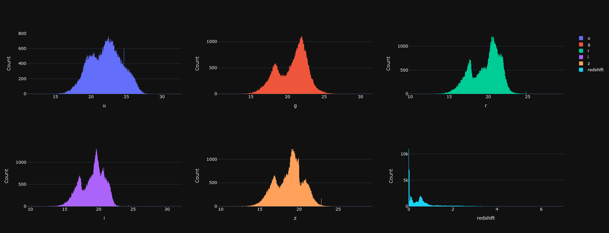

```python
fig = plot_distributions(X_train)
fig.show()
```

```python
X_train.info()
```

```
<class 'pandas.core.frame.DataFrame'>
Int64Index: 79999 entries, 64470 to 15795
Data columns (total 6 columns):
 #   Column    Non-Null Count  Dtype
---  ------    --------------  -----
 0   u         79999 non-null  float64
 1   g         79999 non-null  float64
 2   r         79999 non-null  float64
 3   i         79999 non-null  float64
 4   z         79999 non-null  float64
 5   redshift  79999 non-null  float64
dtypes: float64(6)
memory usage: 4.3 MB
```

```python
X_train.describe()
```

|  | u | g | r | i | z | redshift |
| --- | --- | --- | --- | --- | --- | --- |
| count | 79999.000000 | 79999.000000 | 79999.000000 | 79999.000000 | 79999.000000 | 79999.000000 |
| mean | 22.079781 | 20.629821 | 19.645693 | 19.084133 | 18.769633 | 0.576569 |
| std | 2.253981 | 2.037896 | 1.855367 | 1.756956 | 1.766879 | 0.730559 |
| min | 10.996230 | 10.498200 | 9.822070 | 9.469903 | 9.612333 | -0.009971 |
| 25% | 20.348990 | 18.965320 | 18.137710 | 17.734345 | 17.463695 | 0.054117 |
| 50% | 22.177960 | 21.095470 | 20.122800 | 19.405150 | 19.004470 | 0.423072 |
| 75% | 23.689215 | 22.123990 | 21.046840 | 20.394745 | 19.921020 | 0.704613 |
| max | 32.781390 | 31.602240 | 29.571860 | 32.141470 | 29.383740 | 7.011245 |

#### Scaling

The above distributions are multimodal, and therefore not perfectly normal. It would probably help our classification algorithms if we were to normalize and scale each variable.

Additionally, `redshift` is a very skewed distribution, that represents the expansion of space from the light received from that object. (Think: redshift $\propto$ distance). In the below equation, let $z$ = redshift.

$$ z = \frac{\lambda_{obs}}{\lambda_{rest}} - 1 $$

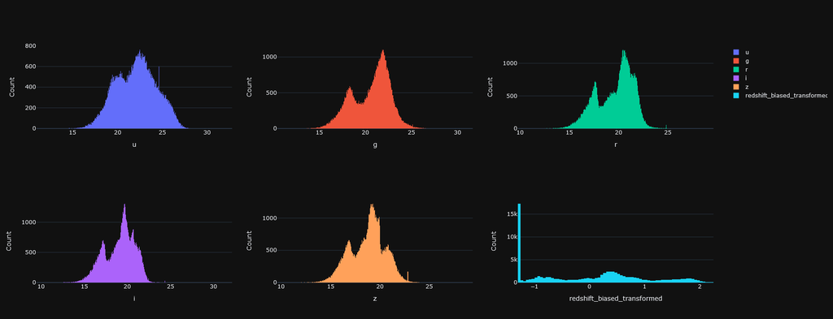

```python
from sklearn.preprocessing import StandardScaler, PowerTransformer

# transform redshift first
redshift_train = X_train['redshift'].copy()
redshift_train = redshift_train.to_numpy().reshape(-1,1)
redshift_test = X_test['redshift'].copy()
redshift_test = redshift_test.to_numpy().reshape(-1,1)

# there are negative values, so we want to bias
bias = 1
redshift_train = redshift_train + bias
redshift_test = redshift_test + bias



# Power Transformer
PT = PowerTransformer(method='yeo-johnson')
PT.fit(redshift_train)
redshift_train = PT.transform(redshift_train)
redshift_test = PT.transform(redshift_test)
X_train['redshift_biased_transformed'] = redshift_train
X_test['redshift_biased_transformed'] = redshift_test

X_train.drop("redshift", axis=1, inplace=True)
X_test.drop("redshift", axis=1, inplace=True)

# updated features list
features.remove("redshift")
features.append("redshift_biased_transformed")

# log transform
# redshift = np.log(redshift)
# X_train['redshift_bias_transformed'] = redshift
# X_train.describe()

fig = plot_distributions(X_train)
fig.show()
```

```python
X_train['redshift_biased_transformed'].isna().sum()
```

```
0
```

Looking at the above `redshift_biased_transformed` distribution, we see there is still a large number of objects at very low redshifts ($>15k$). This distribution, alongside the multimodal distributions of the other features makes me want to apply a clustering algorithm and inspect the relationship between the features further.

```
['u', 'g', 'r', 'i', 'z']
```

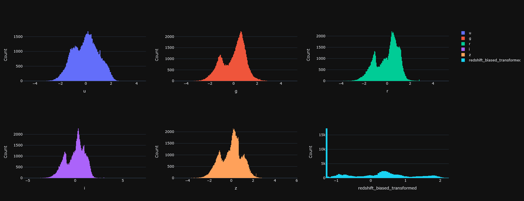

```python
# we dont want to work with the redshift data here


scaled_features = features[:-1]
print(scaled_features)


SS = StandardScaler()
SS.fit(X_train[scaled_features])
X_train_scaled = SS.transform(X_train[scaled_features])
X_test_scaled = SS.transform(X_test[scaled_features]) # use SS fit to the train set to transform the test set.


X_train_scaled = pd.DataFrame(X_train_scaled, columns=scaled_features)
X_test_scaled = pd.DataFrame(X_test_scaled, columns=scaled_features)

X_train_scaled['redshift_biased_transformed'] = X_train['redshift_biased_transformed'].reset_index(drop=True)
X_test_scaled['redshift_biased_transformed'] = X_test['redshift_biased_transformed'].reset_index(drop=True)

X_train = X_train_scaled
X_test = X_test_scaled

fig = plot_distributions(X_train)
fig.show()
```

### Label Distributions

```python
def plot_pie(data, title_str):

    fig = px.pie(data, names="class")

    fig.update_layout(
        template="plotly_dark",
        title={
                "text":title_str,
                "x":0.5
            }
    )

    return fig
```

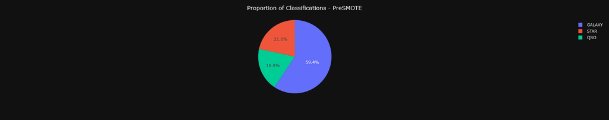

```python
fig = plot_pie(Y_train, "Proportion of Classifications - PreSMOTE" )
fig.show()
```

From the above distribution, we can see there is a class imbalance. `GALAXY` makes up ~60% of the labels, leaving ~40% to both the `STAR` and `QSO` labels. We should balance these labels using `SMOTE` and see if our performance increases.

```python
from imblearn.over_sampling import SMOTE
sm = SMOTE(random_state=42)
X_train, Y_train = sm.fit_resample(X_train, Y_train)
```

[figure not shown]

```python
fig = plot_pie(Y_train, f"Proportion of Classifications - PostSMOTE - {len(Y_train)/len(df)*100:.1f}% more data")
fig.show()
```

Final step is to use label encoding to map each of the unique outputs to an integer (either dense or sparse)

```python
from sklearn.preprocessing import LabelEncoder
le = LabelEncoder()

# train
le.fit(Y_train['class'])
Y_train['class'] = le.transform(Y_train['class'])

# test
Y_test['class'] = le.transform(Y_test['class'])
```

## Modeling

I will leverage a few models and compare the performance of each:

1. Logistic Regression
2. Decision Tree
3. GB Descent
4. Random Forest
5. Support Vector Machine
6. K-Nearest Neighbors
7. Neural Networks (???)

#### Logistic Regression

```python
from sklearn.linear_model import LogisticRegression
from sklearn.metrics import classification_report, confusion_matrix
model = LogisticRegression()
model.fit(X_train, Y_train)
```

```
LogisticRegression()
```

```python
predictions = model.predict(X_test)
predictions
```

```
array([1, 2, 2, ..., 2, 0, 2])
```

```python
report = classification_report(Y_test, predictions)
```

```python
print(report)
```

```
              precision    recall  f1-score   support

           0       0.98      0.94      0.96     11904
           1       0.87      0.93      0.89      3810
           2       0.96      1.00      0.98      4286

    accuracy                           0.95     20000
   macro avg       0.93      0.95      0.94     20000
weighted avg       0.95      0.95      0.95     20000
```

```python
cm = confusion_matrix(Y_test, predictions)
cm
```

```
array([[11181,   548,   175],
       [  284,  3526,     0],
       [    0,     2,  4284]], dtype=int64)
```

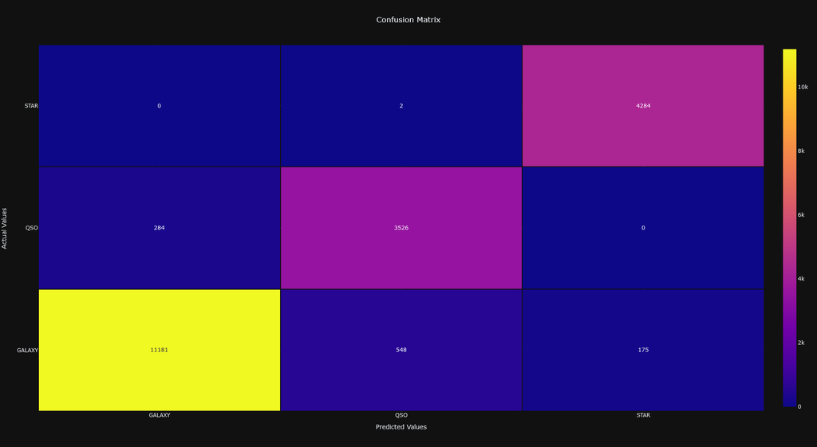

```python
# def plot_confusion_matrix(cm):

fig = go.Figure()
fig.add_trace(
    go.Heatmap(
        z = cm,
        x = le.inverse_transform([0,1,2]),
        y = le.inverse_transform([0,1,2]),
        xgap=2,
        ygap=2,
        text = cm,
        texttemplate="%{text}",
    )
)

fig.update_xaxes(title_text="Predicted Values")
fig.update_yaxes(title_text="Actual Values")

fig.update_layout(
    template="plotly_dark",
    height=1000,
    title={
        'text':'Confusion Matrix',
        'x' : 0.5
    }
)
```